# Modelo individual: fase de contágio

- Nestas notas, vamos analisar a fase de contágio

## Infecções secundárias e tempo de recuperação

- O tempo de recuperação está diretamente ligado à taxa de infecções secundárias.
- Vamos considerar, para efeito de análise, uma rede completa com $n$ indivíduos, e.g. escolar ou de trabalho.
- Vamos começar analisando o modelo já implementado, com força de infecção constante $\beta$ por um tempo médio $1/\gamma$.
- Em seguida, analisamos o modelo tratado pelo grupo do Imperial/Pitt.

## Rede completa com taxas constantes

### Infectados secundários

- No modelo individual com taxa de infecção e recuperação constantes, um indivíduo infectado contribui para a força de infecção de um indivíduo suscetível com a taxa $\beta/n$, durante um tempo médio $1/\gamma$.
- O termo $\beta/n$ é a taxa de contágio por unidade de tempo. Ao longo de um intervalo de tempo $1/\gamma$, a probabilidade de contágio de um certo suscetível é

$$ \frac{\beta}{n\gamma}. $$

- Contando a população toda de suscetíveis, temos o seguinte valor esperado de infectados secundários:

$$ \frac{\beta}{\gamma} $$

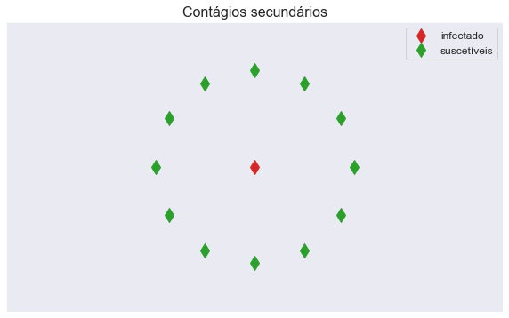

```python
N = 12
x = np.array([np.cos(2*n*np.pi/N) for n in range(N)])
y = np.array([np.sin(2*n*np.pi/N) for n in range(N)])

plt.figure(figsize=(10,6))
plt.plot(0,0, 'd', color='tab:red', markersize=12, label='infectado')
plt.plot(x, y, 'd', color='tab:green', markersize=12, label='suscetíveis')
plt.xlim([-2.5, 2.5])
plt.ylim([-1.5, 1.5])
plt.xticks([])
plt.yticks([])
plt.legend(fontsize=12)
plt.title('Contágios secundários', fontsize=16)
plt.show()
```

### Número básico de reprodução

- Obtivemos, assim, um número médio de contágios secundários de $\beta/\gamma$.
- Por definição, esse número médio de contágios secundários é exatamente o $\mathcal{R}_0$.

### O denominador na força de infecção

- Vale ressaltar que o correto seria usar $n-1$, no lugar de $n$, mas, para populações grandes, essa diferenção não é muito significativa.
- Para as residências, no entando, isso é significativo, mas, nesse caso, o modelo usa um ajuste com $n^\alpha$, $\alpha=0.8$.
- O artigo Pellis, Ball & Trapman P (2012), por exemplo, utiliza $n-1$, corroborando a heurística acima.

### Ajuste para populações pequenas

- Vamos, aqui, apenas visualizar o efeito do ajuste $n^\alpha$, comparado com $(n-1)$, no caso de populações pequenas, como em uma residência.
- Observe que, para $n=1$, isso é irrelevante, pois é preciso pelo menos um infectado e um suscetível para haver infecção.

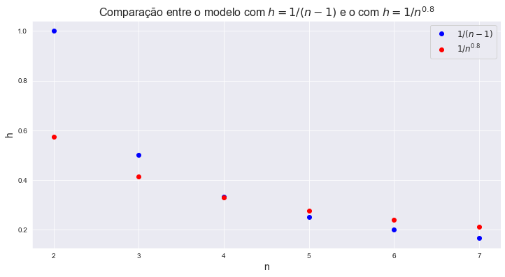

```python
plt.figure(figsize=(12,6))
n = np.arange(2, 8)
plt.plot(n, 1/(n-1), 'bo', label='$1/(n-1)$')
plt.plot(n, 1/n**0.8, 'ro', label='$1/n^{0.8}$')
plt.ylabel('h', fontsize=14)
plt.xlabel('n', fontsize=14)
plt.title('Comparação entre o modelo com $h=1/(n-1)$ e o com $h=1/n^{0.8}$',
          fontsize=16)
plt.legend(fontsize=12)
plt.show()
```

### Potência ótima contando residências de até oito indivíduos

```python
@np.vectorize
def e(a, N):
    return np.sum([(1/(n-1) - 1/n**a)**2 for n in range(2, N+1)])
```

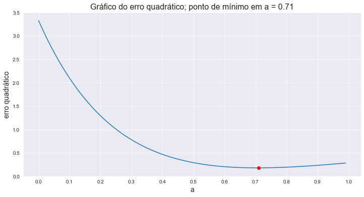

```python
plt.figure(figsize=(12,6))
N = 8
a = np.arange(0, 1, 0.01)
a_min = a[e(a, N).argmin()]
e_min = e(a_min, N)
plt.plot(a, e(a, N))
plt.plot(a_min,e_min, 'ro')
plt.ylim([0,3.5])
plt.xticks([j*0.1 for j in range(11)])
plt.xlabel('a', fontsize=14)
plt.ylabel('erro quadrático', fontsize=14)
plt.title('Gráfico do erro quadrático;'
          + f' ponto de mínimo em a = {a_min}', fontsize=16)
plt.show()
```

### Potência ótima considerando residências maiores

```python
for N in (6, 8, 10, 12, 14, 16, 17, 18, 20):
    print(f'Até {N} indivíduos: {a[e(a, N).argmin()]}')
```

```
Até 6 indivíduos: 0.65
Até 8 indivíduos: 0.71
Até 10 indivíduos: 0.74
Até 12 indivíduos: 0.76
Até 14 indivíduos: 0.78
Até 16 indivíduos: 0.79
Até 17 indivíduos: 0.8
Até 18 indivíduos: 0.8
Até 20 indivíduos: 0.81
```

## SIR compartimental

Lembremos alguns aspectos do modelo SIR compartimental, que é determinístico.

### Taxa de infecção

- Lembremos que, no modelo determinístico, não há probabilidades, apesar dos termos serem baseados em interpretações probabilísticas.
- Assim, temos
  - $\beta$ é a **taxa de potencial de contágio por unidade de tempo por indivíduo suscetível**;
  - $\beta=\tau\kappa$, onde $\tau$ representa uma fração de **potencial de contágio por contato** e $\kappa$, a **taxa de número de contatos por indivíduo por unidade de tempo**. O "potencial de contágio por contato" representa a fração de contatos onde há contágio caso o contato seja com um indivíduo suscetível. Digamos, se uma fração dos seus contatos diários espirra na sua frente, ou conversa muito próximo a você, etc., pode haver contágio, caso este indivíduo esteja infectado. Ou seja, o termo "potencial" se refere à dependência do contato ter que ser com um infectado para haver, de fato, contágio.
  - $I/n$ é a fração de infectados na população;
  - $\beta I/n$ é taxa de contágio por indivíduo suscetível, ou seja, a fração dos contatos com potencial de contágio em que o potencial é realizado.
  - $\beta I S/n$ é a taxa de infecção do conjunto de todos os suscetíveis.
- Juntando com a **taxa de recuperação** $\gamma I$, chegamos à equação diferencial para $I$:

$$ \frac{\textrm{d} I}{\textrm{d} t} = \frac{\beta}{n}IS - \gamma I. $$

- As equações para os suscetíveis e os recuperados são

$$ \frac{\textrm{d} S}{\textrm{d} t} = - \frac{\beta}{n}IS, \qquad \frac{\textrm{d} R}{\textrm{d} t} = \gamma I. $$

### Número básico de reprodução

- Olhando apenas para o termo $\beta IS/n$ podemos aproximar o total de "novos" infectados por

$$ \Delta I = I(t+\Delta t) - I(t) \approx \frac{\beta}{n}IS \Delta t. $$

- Interpretando $1/\gamma$ como o tempo médio de recuperação, temos que, durante esse tempo $\Delta t = 1/\gamma$, temos

$$ \Delta I \approx \frac{\beta}{n\gamma}IS. $$

- Assumindo que, no início da epidemis, $I=1$ e $S\approx n$, então

$$ \Delta I \approx \frac{\beta}{\gamma}. $$

- Este é o número básico de reprodução.
- Observe que se usarmos a formulação mais correta de

$$ \frac{\textrm{d} I}{\textrm{d} t} = \frac{\beta}{n-1}IS - \gamma S, $$

obtemos, diretamente, para $I=1$ e $S=n-1$, que

$$ \mathcal{R_0} \sim \Delta I \approx \frac{\beta}{\gamma}. $$

- Mas não esqueça que aproximamos a evolução por um passo de Euler.

### Outra forma do número básico de reprodução

- Integrando a equação para $I$ como uma equação de primeira ordem

$$ \frac{\textrm{d} I}{\textrm{d} t} = \left(\frac{\beta}{n}S - \gamma\right) I, $$

obtemos

$$ I(t) = I(t_0)e^{\displaystyle \left(\gamma t - \frac{\beta}{n}\int_{t_0}^t S(s)\;\textrm{d} s\right)}. $$

- Considerando $n\gg 1$, $t = t_0 + 1/\gamma$ e aproximando $S(t) \approx n$ no intervalo entre $t_0$ e $t$, temos

$$ I(t) \approx I(t_0) e^{\displaystyle \left(1- \frac{\beta}{\gamma}\right)}. $$

- Portanto, neste intervalo, temos um incremento do número de infectados de aproximadamente

$$ \mathcal{R}_0 \sim \Delta I = I(t) - I(t_0) \approx I(t_0)\left( e^{\displaystyle \left(1- \frac{\beta}{\gamma}\right)} - 1 \right). $$

- É claro que podemos aproximar uma exponencial $e^x$ por $1 + x$ e obter a aproximação anterior $\mathcal{R}_0 \sim \Delta I \approx \beta/\gamma$.

### Tempo de recuperação no SIR compartimental

- O termo $1/\gamma$ é interpretado como o tempo médio de recuperação.
- Integrando-se a equação $R'=\gamma I$ em um intervalo $[t, t + 1/\gamma]$, temos que o total de recuperados neste intervalo é igual a média do número de infectados neste mesmo período:

$$ \Delta R = R(t+1/\gamma) - R(t) = \int_t^{t+1/\gamma} R'(s)\;\mathrm{d}s = \gamma \int_t^{1/\gamma} I(s)\;\mathrm{d}s = \frac{1}{\frac{1}{\gamma}}\int_t^{1/\gamma} I(s)\;\mathrm{d}s = \textrm{média de $I$ no intervalo $[t,t+1/\gamma]$}. $$

Assim

$$ \gamma = \frac{1}{\textrm{tempo de infecção}} $$

- Mas isso não é a mesma coisa que dizer que $1/\gamma$ é o tempo médio de recuperação.

### Mediana do tempo de recuperação

- Assumindo que no instante $t=0$ temos $I_0$ infectados e que, a partir desse momento, mais nenhum indivíduo é infectado, temos $I(s) = I_0 e^{-\gamma s}$, de modo que

$$ \Delta R = \gamma I_0 \int_0^T e^{-\gamma s} \;\textrm{d} s = I_0\left(1 - e^{-\gamma T}\right). $$

- Dessa fórmula, podemos tirar a **mediana** do tempo de recuperação equacionando

$$ \Delta R = \frac{I_0}{2} $$

- Logo,

$$ 1 - e^{-\gamma T} = \frac{1}{2}, $$

- Denotando esse tempo por $T_{1/2}$ (assim como a meia-vida de um elemento radioativo), temos

$$ e^{-\gamma T_{1/2}} = \frac{1}{2} \quad \Longleftrightarrow \quad T_{1/2} = \frac{1}{\gamma}\ln 2. $$

Assim, $T_{1/2}$ é a **mediana** do tempo de recuperação.

### Recuperados ao longo do tempo

- Escrevemos $\Delta R = \Delta R(T)$ explicitamente em função de $T$:

$$ \Delta R(T) = R(T) - R(0) = \int_0^T R'(s) \;\textrm{d} s = \gamma \int_0^T I(s) \;\textrm{d} s. $$

- Assumindo, novamente, que no instante $t=0$ temos $I_0$ infectados e que, a partir desse momento, mais nenhum indivíduo é infectado, temos $I(s) = I_0 e^{-\gamma s}$, de modo que

$$ \Delta R(T) = \gamma I_0 \int_0^T e^{-\gamma s} \;\textrm{d} s = I_0\left(1 - e^{-\gamma T}\right). $$

- Isso nos dá o **número de recuperados ao longo de um tempo $T$**.
- Podemos inverter e escrever o **tempo decorrido para se recuperar $\Delta R$ indivíduos**:

$$ e^{-\gamma T} = 1 - \frac{\Delta R}{I_0} $$

- Explicitamente,

$$ T = -\frac{1}{\gamma} \ln\left( 1 - \frac{\Delta R}{I_0}\right). $$

### Tempo médio de recuperação

- Quando $\Delta R = I_0$, então todos os infectados estão recuperados.
- O tempo médio $\bar T_r$ para que os $I_0$ infectados sejam recuperados é dado por

$$ \bar T_r = \frac{1}{I_0}\int_0^{I_0} T(\Delta R) \;\mathrm{d}\Delta R. $$

- Logo,

$$ \bar T_r = \frac{1}{\gamma I_0} \int_0^{I_0} \ln\left(1 - \frac{\Delta R}{I_0}\right) \;\mathrm{d}\Delta R. $$

- Fazendo $\rho = 1 - \Delta R/I_0$ e, em seguida, $r = -\ln \rho$, temos

$$ \bar T_r = - \frac{1}{\gamma}\int_0^1 \ln \rho \;\mathrm{d}\rho = \frac{1}{\gamma}\int_0^{\infty} r e^{-r} \;\mathrm{d} r = \cdots = \frac{1}{\gamma}. $$

- Portanto, $1/\gamma$ pode ser, de fato, interpretado como valor médio para o tempo de recuperação.

## Modelo individual estocástico com taxas constantes em rede completa

- Consideramos, inicialmente, o modelo estocástico individual com taxas constantes $\beta$ e $\gamma$, rede completa com $n$ indivíduos e passo de tempo $\Delta t$.
- A força de infecção agindo em cada indivíduo suscetível $i$ é

$$ \lambda_i = \frac{\beta}{n} \sum_{j\neq i} I_j $$

onde $I_j = 1$, se o indivíduo $j$ está infectado, ou $I_j=0$, caso contrário (suscetível ou recuperado).

- Um indivíduo $i$ suscetível se torna infectado de acordo com testes de Bernoulli com probabilidade de infecção de

$$ p_\text{infecção} = 1 - e^{-\lambda_i \Delta t}. $$

- O indivíduo infectado se torna recuperado de acordo com testes de Bernoulli com probabilidade de recuperação de

$$ p_\text{recuperação} = 1 - e^{-\gamma \Delta t}. $$

### Tempo de recuperação

- O tempo de recuperação é dado por testes de Bernoulli, com probabilidade de sucesso dada por $p_\text{recuperação} = 1 - e^{- \gamma \Delta t}$.
- Essa sucessão de testes independentes com mesma probabilidade de sucesso forma um **processo de Bernoulli**.
- O **tempo de recuperação** é o **tempo de espera** *(waiting time)* de sucesso do processo.
- Como os testes são independentes, o **tempo de espera** é uma probabilidade $\mathcal{P}$ "*sem memória*".
- Uma probabilidade discreta $\mathcal{P}$ é **sem memória** quando a probabilidade do tempo de espera ser maior do que $n+m$ dado que é maior do que $n$ é a mesma que a probabilidade do tempo de espera ser maior do que $m$, que é a diferença entre os dois tempos ($n$ e $m$ inteiros não negativos):

$$ \mathcal{P}(n \geq m + k \;| \;n \geq m) = \mathcal{P}(n \geq k). $$

- Na verdade, como estamos falando em tempos discretos múltiplos de um determinado passo $\Delta t$, a condição de ser sem memória deve ser expressa na forma dimensionalmente correta:

$$ \mathcal{P}(T \geq (m + k)\Delta t \;| \;T \geq m\Delta ) = \mathcal{P}(T \geq k\Delta t). $$

- A única distribuição discreta sem memória é a **distribuição geométrica**, caracterizada pela **função massa de probabilidade (FPM)** (ou *probability mass function - pmf*)

$$ p(k) = \mathcal{P}(\tau = k) = (1-p)^{k-1}p, $$

com $0<p\leq 1$ e $p=p(1)=\mathcal{P}(\tau=1)$.

- A demonstração disso faz uso da expressão para probabilidade condicional

$$ \tilde{\mathcal{P}}(n \geq m + k\;| \;T \geq m) = \frac{\tilde{\mathcal{P}}(n \geq m + k)}{\tilde{\mathcal{P}}(n \geq m)}, $$

- Na verdade, como a variável aleatória $T$ tem unidade de tempo e estamos evoluindo a passos discretos $\Delta t$, devemos considerar

$$ p(T) = \mathcal{P}(t = k\Delta t) = (1 - p)^{k-1}p, $$

com $p=\mathcal{P}(T=\Delta t) = p_\text{recuperação} = 1 - e^{- \gamma \Delta t}$.

- Observe que, no nosso caso, considerando, então, que o tempo de recuperação é dado por uma distribuição geométrica $\mathcal{P}(T=k\Delta t) = (1-p)^{k-1}p$, com

$$ p = \mathcal{P}(T=\Delta t) = p_\text{recuperação} = 1 - e^{-\gamma \Delta t}, $$

temos

$$ \mathcal{P}(T=k\Delta t) = e^{-\gamma k\Delta t}(1-e^{-\gamma \Delta t}). $$

- Aproximando a exponencial, temos

$$ \mathcal{P}(T=k\Delta t) \approx \gamma \Delta t e^{-\gamma k\Delta t} + \mathcal{O}(\gamma^2 \Delta t^2). $$

### Processos de Poisson

- Enquanto processos de Bernoulli como acima estão associados a distribuições discretas, a versão contínua está ligada a **processos de Poisson**, onde os eventos ocorrem em tempo contínuo, também independentes entre si, e a taxas constantes no tempo.
- No caso contínuo, a única distribuição sem memória é a exponencial, $\mathcal{P}(T \geq t) = e^{-\alpha t}$, $t\geq 0$, onde $\alpha$ é a taxa de probabilidade de sucesso por unidade de tempo.
- A demonstração desse fato, no caso contínuo, é semelhante à do caso discreto, com a diferença de que $\alpha$ é encontrado via limite de diferenças finitas (derivada).}
- Aproximando pelo caso contínuo, temos as duas igualdades

$$ \mathcal{P}(T>\Delta t) = 1 - p_\textrm{recuperação} = e^{-\gamma \Delta t} \quad \text{e} \quad \mathcal{P}(T > \Delta t ) = e^{ -\alpha \Delta t}, $$

- Logo

$$ \alpha = \gamma = - \frac{1}{\Delta t}\ln \mathcal{P}(T > \Delta t). $$

- Na verdade, o caso discreto é uma aproximação do modelo contínuo, em que $\gamma$ já é a taxa de probabilidade de recuperação por unidade de tempo.
- A PDF $f_\mathcal{P}$ da probabilidade exponencial é a derivada da distribuição acumulada $\mathcal{P}(T \leq t) = 1 - \mathcal{P}(T > t) = e^{-\gamma t}$, ou seja

$$ f_\mathcal{P}(t) = \gamma e^{-\gamma t}. $$

- Note que

$$ \begin{multline*} \mathcal{P}(k\Delta t \leq t < (k+1)\Delta t) = \int_{k\Delta t}^{(k+1)\Delta t} f_\mathcal{P}(t) \;\textrm{d}t = \int_{k\Delta t}^{(k+1)\Delta t} \gamma e^{-\gamma t} \;\textrm{d}t \\ = e^{-\gamma k\Delta t } - e^{-\gamma (k+1)\Delta t } = e^{-\gamma k\Delta t }\left(1 - e^{-\gamma \Delta t}\right), \end{multline*} $$

coincidindo com a FMP da distribuição geométrica.

### Tempo médio de recuperação

- Considerando a distribuição geométrica para o tempo de recuperação, temos que o tempo médio de recuperação é a média dessa distribuição, que é $1/p$, onde $p$ é a probabilidade de sucesso do teste de Bernoulli.
- Mas como, na verdade, estamos considerando a variável aleatória como assumindo valores que são múltiplos da unidade de tempo $\Delta t$, o tempo médio é

$$ \bar T = \frac{\Delta t}{p}. $$

- Dessa forma, o **tempo médio de recuperação** é

$$ \bar T_r = \frac{\Delta t}{1 - e^{- \gamma \Delta t}}. $$

- Aproximando a exponential por $e^x \approx x + \mathcal{O}(x^2)$, obtemos

$$ \bar T_r \approx \frac{1}{\gamma}. $$

- Por sua vez, com a distribuição exponencial $e^{-\gamma t}$, sabendo que o valor médio de uma distribuição exponencial é $1/\gamma$, obtemos, novamente, o mesmo tempo médio de recuperação

$$ \bar T_r = \frac{1}{\gamma}. $$

### Ilustrando numericamente a função probabilidade de massa do tempo de espera em testes de Bernoulli

```python
def drawing(beta, count_max, N):
    def wait(beta):
        m = 1
        while rng.random() < np.exp(-beta): # failure
            m += 1
        return m
    rng = np.random.default_rng()
    count = np.zeros(count_max)
    for j in range(N):
        m = wait(beta)
        if m < count_max:
            count[m] += 1
    return count
```

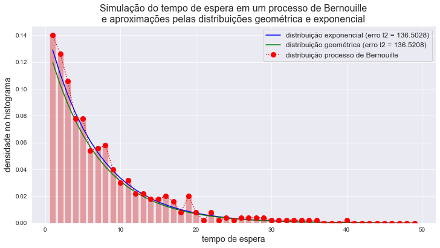

```python
beta = 0.15
prob = 1 - np.exp(-beta)
N = 500
count_max = 50
p = drawing(beta, count_max, N)[1:]
ks = np.array([k+1 for k in range(count_max-1)])
p_exp = beta*np.exp(-beta*ks)
p_geom = prob*(1-prob)**ks
plt.figure(figsize=(12,6))
plt.plot(ks,p_exp, 'b-', label=f'distribuição exponencial (erro l2 = {np.linalg.norm(p_exp - p):.4f})')
plt.plot(ks,p_geom, 'g-', label=f'distribuição geométrica (erro l2 = {np.linalg.norm(p_geom - p):.4f})')
plt.plot(ks, p/N, 'ro:', markersize = 8, label='distribuição processo de Bernouille')
plt.bar(ks, p/N, color='tab:red', alpha=0.4)
plt.legend(fontsize=12)
plt.xlabel('tempo de espera', fontsize=14)
plt.ylabel('densidade no histograma', fontsize=14)
plt.title('Simulação do tempo de espera em um processo de Bernouille\n'
          + 'e aproximações pelas distribuições geométrica e exponencial', fontsize=16)
plt.show()
```

### Número básico de reprodução

- Vamos considerar, novamente, a situação inicial de um único indivíduo infectado e $n-1$ suscetíveis.
- A cada passo de tempo, a probabilidade de um indivíduo suscetível ser infectado (por esse único indivíduo infectado) é

$$ p_\text{infecção} = 1 - e^{-\lambda_i \Delta t}, \qquad \text{onde} \quad \lambda_i = \frac{\beta}{n}. $$

- Se o indivíduo infectado continua contagioso durante $k$ passos de tempo, então a probabilidade de contágio de um indivíduo suscetível aumenta para

$$ kp_\text{infecção} = k(1 - e^{-\lambda_i \Delta t}). $$

- Considerando um tempo médio de recuperação de $k\Delta t \approx 1/\gamma$, então, durante o seu período contagioso, a probabilidade desse infectado ter contagiado um suscetível é de

$$ \frac{1}{\gamma \Delta t} p_\text{infecção} = \frac{1}{\gamma \Delta t}(1 - e^{-\lambda_i \Delta t}). $$

- Aproximando a exponencial, temos

$$ \frac{1}{\gamma \Delta t}(1 - e^{-\lambda_i \Delta t}) \approx \frac{\lambda_i}{\gamma} = \frac{\beta}{n\gamma}. $$

- Contando todos os indivíduos, obtemos um número esperado de casos secundários, que é exatamente o **número básico de reprodução**, de

$$ \mathcal{R_0} = \frac{n}{\gamma \Delta t} p_\text{infecção} = \frac{n}{\gamma \Delta t}(1 - e^{-\lambda_i \Delta t})\approx \frac{\beta}{\gamma}. $$

### Tempo de geração

- Na página 16 das notas suplementares de Ferguson et al (2006), consta que, no trabalho em questão, o **tempo de geração** é considerado como sendo o *tempo médio do período contagioso*, e teria o valor de 2.6 dias.
- Mas essa não é a definição padrão!
- Uma outra definição de tempo de geração, mais comum (ver Svensson (2007) para uma boa discussão sobre isso), está relacionada com os intervalos de tempo entre os casos primários e os secundários.
- Na verdade, há duas maneiras diferentes de se caracterizar esse intervalo.
- Uma é chamada de *backward generation time*, em que olhamos a partir dos casos secundários e tomamos a média em relação tempo levado para eles fossem infectados pelos casos primários.
- E outra, denominada *forward generation time*, onde a média é tomada relativa aos casos primários.
- Por exemplo, se um infectado contagiou dois suscetíveis após 1 e 2 dias, respectivamente, e um outro infectado contagiou outros 3 suscetíveis em 1, 2 e 3 dias, então o tempo médio de geração do primeiro infectado é 1 1/2 e o do segundo, 2. A média entre os infectados primários é $(3/2 + 2)/2 = 7/4$. Este é o *forward generation time*.
- Por outro lado, considerando os cinco casos secundários, a média é $(1 + 2 + 1 + 2 + 3)/5 = 9/5$. Este é o *backward generation time*.

## Modelo individual estocástico com taxas variáveis em rede completa

### Força de infeccção

- No modelo do Imperial/Pitt, ao invés de uma força de infecção constante $\beta/n$ ao longo de um período $1/\gamma$, temos uma força variável

$$ \lambda(t) = \frac{\beta}{n} \kappa(t;\delta, \eta). $$

- Essa força age em cada indivíduo suscetível $i$ e, mais geralmente, em redes estruturadas, denominamos $\lambda_i$. Mas no caso de uma rede completa, em que temos apenas uma taxa de contágio $\beta$ e não levamos a distância em consideração, a força independe to indivíduo suscetível e podemos denominar simplesmente de $\lambda$.
- Como estamos considerando um modelo a passos discretos $\Delta t$ no tempo, a probabilidade de um indivíduo suscetível ser infectado por um único indivíduo infectado, ao longo de todo o seu período de infecção, é

$$ \sum_{k=1}^\infty \left(1 - e^{-\lambda(t_k)\Delta t}\right), $$

onde $t_k = k\Delta t$.

### Número básico de reprodução

- Nesse caso, juntando todos os suscetíveis, o número de casos secundários, $\mathcal{R}_0$, é dado por

$$ \mathcal{R}_0 = n \sum_{k=1}^\infty \left(1 - e^{-\lambda(t_k)\Delta t}\right). $$

- Aproximando a exponencial, obtemos

$$ n \sum_{k=1}^\infty \left(1 - e^{-\lambda(t_k)\Delta t}\right) \approx n\sum_{k=1}^\infty \lambda(t_k)\Delta t = \beta\sum_{k=1}^\infty \kappa(t_k; \delta, \eta)\Delta t \sim \beta\int_0^\infty \kappa(t;\delta, \eta) \;\textrm{d} t. $$

- Nesse caso, multiplicando por $n$, obtemos uma aproximação para $\mathcal{R}_0$, o número de casos secundários:

$$ \mathcal{R}_0 \approx \beta\int_0^\infty \kappa(t;\delta, \eta) \;\textrm{d} t. $$

- Observe que, no caso de taxa constante $\lambda = \beta/n$ por um período $1/\gamma$, recuperamos, a partir da fórmula acima, o número básico de reprodução $\mathcal{R}_0 = \beta/\gamma$.

### Outro caminho para o número básico de reprodução

- Partimos, novamente, de

$$ \mathcal{R}_0 = n \sum_{k=1}^\infty \left(1 - e^{-\lambda(t_k)\Delta t}\right). $$

- Multiplicando e dividindo por $\Delta t$, obtemos

$$ \mathcal{R}_0 = n \sum_{k=1}^\infty \left(\frac{1 - e^{-\lambda(t_k)\Delta t}}{\Delta t}\right) \Delta t. $$

- Tomando o limite $\Delta t \rightarrow 0$, o somatório converge para uma integral e o integrando para a derivada de $-e^{-\lambda(t)s}$ em $s=0$, de maneira que

$$ \mathcal{R}_0 = n\int_0^\infty \lambda(t) \;\textrm{d} t = \beta\int_0^\infty \kappa(t;\delta, \eta) \;\textrm{d} t, $$

como obtido antes via aproximação da exponencial.

### Modulação da força de infecção

- O termo $\kappa(T; \delta, \eta)$ é assumido como sendo uma distribuição log-normal, com $\delta$ e $\eta$ sendo a média e o desvio-padrão de $\ln T$:

$$ \mathcal{P}(t \leq T) = \mathcal{N}(\ln t \leq \ln T; \delta, \eta) = \mathcal{N}\left(\ln t \leq \frac{\ln T - \delta}{\eta}\right) = \int_{-\infty}^{\displaystyle \frac{\ln T - \delta}{\eta}}\frac{1}{\sqrt{2\pi}} e^{\displaystyle -\frac{s^2}{2}} \;\textrm{d} s, $$

para $T > 0$, com $\mathcal{P}(t \leq T) = 0$, para $T\leq 0$.

- Entendo que $\kappa(T; \delta, \eta)$ seja a PDF dessa distribuição, temos

$$ \kappa(T; \delta, \eta) = \frac{\textrm{d}}{\textrm{d} T} \left(\int_{-\infty}^{\displaystyle \frac{\ln T - \delta}{\eta}}\frac{1}{\sqrt{2\pi}} e^{\displaystyle -\frac{s^2}{2}} \;\textrm{d} s\right) = \frac{1}{\eta T}\left(\frac{1}{\sqrt{2\pi}} e^{\displaystyle -\frac{(\ln T - \delta)^2}{2\eta^2}}\right). $$

- Nas notas suplementares de Ferguson et al (2005),

| Model Parameter | *Posterior* Mean | 95% credible interval |
| --- | --- | --- |
| $\delta(\log(\textrm{day}))$ | -0.72 | -1.64 a -0.09 |
| $\eta(\log(\textrm{day}))$ | 1.8 | 1.3 a 2.5 |

- E no relatório do Imperial College (16/mar/2020), consta, apenas, que

  *... an infectiousness profile over time that results in a 6.5-day mean generation time.*

### Parâmetros

- Também podemos caracterizar uma lognormal através de

$$ \delta^* = e^\delta \qquad \eta^* = e^\eta. $$

- Com essa notação,

$$ \kappa(T; \delta, \eta) = \frac{1}{T\ln\eta^*}\left(\frac{1}{\sqrt{2\pi}} e^{\displaystyle -\frac{(\ln T - \ln \delta^*)^2}{2\ln^2 \eta^*}}\right) = \frac{1}{T\ln\eta^*}\left(\frac{1}{\sqrt{2\pi}} e^{\displaystyle -\frac{\ln^2(T/\delta^*)}{2\ln^2 \eta^*}}\right). $$

- O parâmetro $\delta$ é a média, e também mediana, de $\ln T$, enquanto que $\delta^*$ é a mediana de $T$ e $\eta^*$ é o desvio-padrão multiplicativo. A média é $e^{\eta^2/2}e^\delta$, mas a quantidade relevante para nós, aqui, é a mediana.
- Os intervalos que contém 68%, respectivamente 95%, da probabilidade do tempo de recuperação $T$ são

$$ \frac{\delta^*}{\eta^*} \leq T \leq \eta^*\delta^* \qquad \text{e} \qquad \frac{\delta^*}{{\eta^*}^2} \leq T \leq {\eta^*}^2\delta^*. $$

- Contando a partir de $T=0$, temos os intervalos de 84,2% e 97,7%, respectivamente:

$$ 0 \leq T \leq \eta^*\delta^* \qquad \text{e} \qquad 0 \leq T \leq {\eta^*}^2\delta^*. $$

- Isso significa que as integrais a seguir contém 84,2% e 97,7%, respectivamente, da integral em $(0, \infty)$:

$$ \int_0^{\eta^*\delta^*} \kappa(T; \delta, \eta) \;\textrm{d}T, \qquad \int_0^{{\eta^*}^2\delta^*} \kappa(T; \delta, \eta) \;\textrm{d}T. $$

- Dito de outra forma, pouco mais de 84% dos contágios ocorrem no primeiro intervalo e quase 98%, no segundo intervalo. Por esse ponto de vista, é razoável considerarmos $2\eta^*\delta^*$, ou algum outro múltiplo de $\eta^*\delta^*$, como o tempo de contágio.
- No exemplo tratado em Ferguson et al (2005), temos

| Model Parameter | *Posterior* Mean | 95% credible interval |
| --- | --- | --- |
| $\delta^*(\textrm{day})$ | 0.487 | 0.194 a 0.914 |
| $\eta^*(\textrm{day})$ | 6.04 | 3.67 a 12.18 |

- Mas isso nos daria ${\eta^*}^2\delta^* \approx 17.77$ dias de contágio, o que é bem maior do que os 2,6 dias mencionados no artigo.

### Dimensionalidade

- Alguns problemas:
  - Funções trancendentais, como exponenciais e logaritmos, assim como as funções trigonométricas, não devem ser aplicadas diretamente a quantidades dimensionais. Devemos adimensionalizá-las antes.
  - De fato, por exemplo, se $q_1$ e $q_2$ são duas quantidades dimensionais com a mesma dimensão $Q$, ao considerarmos $\ln q_1$ e $\ln q_2$, teríamos, por um lado, $\ln q_1$ e $\ln q_2$ com dimensão $\ln Q$, mas, por outro lado, $\ln q_1 - \ln q_2 = \ln(q_1/q_2)$ seria adimensional. Inconsistências semelhantes aparecem nas outras funções mencionadas acima.
  - Por outro lado, para que a dimensão física do numerador do termo da exponencial tenha sentido, é preciso que $$ \left[ \delta \right] = \ln \textrm{(tempo)} \quad \text{ e } \left[ \eta \right] = \ln \textrm{(tempo)}. $$
  - Mesmo que isso fosse aceitável, $\kappa$ não seria adimensional, pois teria $\eta T$ no denominador, levando a $$ \left[ \kappa \right] = \frac{1}{\textrm{(tempo)} \ln \textrm{(tempo)}}. $$
  - Mas para que a força de infecção tenha dimensão de $1/\textrm{tempo}$ e para que o tempo de geração seja adimensional, é preciso que $\kappa=\kappa(T; \delta, \eta)$ seja adimensional.
  - Sobre formulações matemáticas para se trabalhar com quantidades dimensionais [Terry Tao's A mathematical formalisation of dimensional analysis](https://terrytao.wordpress.com/2012/12/29/a-mathematical-formalisation-of-dimensional-analysis/), [Dan Jonsson's Quantities, dimensions, and Dimensional analysis](https://arxiv.org/abs/1408.5024)

### Uma possibilidade

- A questão é entender, dadas as incongruências acima, como é, de fato, a forma de $\kappa$ considerada pelo Imperial/Pitt.
- Uma possibilidade, para que a exponencial e os logaritmos tenham dimensões físicas apropriadas, é começarmos com um modulador $\tilde \kappa$ da forma

$$ \tilde\kappa(T; \delta, \eta) = \frac{1}{T}\left(\frac{1}{\eta\sqrt{2\pi}} e^{\displaystyle -\frac{(\ln(T) - \delta)^2}{2\eta^2}}\right), $$

onde $e^{\delta}$ tem dimensão de $\textrm{tempo}$, mas $\eta$ é adimensional.

- Usando que $\ln T - \delta = \ln T - \ln e^\delta = \ln (T/e^\delta) = \ln(e^{-\delta} T)$, isso pode ser escrito na forma

$$ \tilde\kappa(T; \delta, \eta) = \frac{1}{T}\left(\frac{1}{\eta\sqrt{2\pi}} e^{\displaystyle -\frac{\ln^2(e^{-\delta} T)}{2\eta^2}}\right), $$

para $T\geq 0$.

- Essa função $\tilde\kappa$ é, de fato, a PDF de uma lognormal.
- E pode ser vista como a lognormal de $T/e^{-\delta}$ com média $1$ e desvio padrão $\eta$, tudo adimensional.
- Além disso, está na forma implementada em [scipy.stats.lognorm](https://docs.scipy.org/doc/scipy/reference/generated/scipy.stats.lognorm.html), com `s`=$\eta$ e `scale`=$e^{\delta}$:

```
lognorm.pdf(T, s=eta, scale=np.exp(delta)) \
    = lognorm.pdf(T/np.exp(delta), s=eta, scale=1)/np.exp(delta)
```

- Mas observe que $\tilde\kappa$ tem dimensão de $(\textrm{tempo})^{-1}$, o que, em termos gerais, não é problema, já que ao integrarmos em $T$, a integral obtida é adimensional, pois $\mathrm{d}T$ tem dimensão de tempo, nos dando uma medida de probabilidade. Mas, no nosso caso, precisamos de um função adimensional.
- Uma saida é considerar $\kappa$ como sendo um múltiplo da pdf $\tilde\kappa$, com esse fator multiplicativo tendo dimensão inversa de tempo, gerando um novo parâmetro, digamos $\zeta$:

$$ \kappa(T; \zeta, \delta, \eta) = \frac{1}{\zeta T}\left(\frac{1}{\eta\sqrt{2\pi}} e^{\displaystyle -\frac{\ln^2(e^{-\delta} T)}{2\eta^2}}\right), $$

para $T\geq 0$.

### Número básico de reprodução

- Fazendo $\tau = e^{-\delta} T$, temos $\mathrm{d}T = e^\delta\mathrm{d}\tau$ e

$$ \frac{\beta}{n}\int_0^\infty \kappa(T; \zeta, \delta, \eta) \;\textrm{d}T = \frac{\beta}{n\zeta}\int_0^\infty \frac{1}{\tau}\left(\frac{1}{\eta\sqrt{2\pi}} e^{\displaystyle -\frac{\ln^2(\tau)}{2\eta^2}}\right) \;\textrm{d}\tau = \frac{\beta}{n\zeta}. $$

- Considerando a situação de uma rede completa com um único indivíduo infectado, o número acima nos dá as chances de termos um suscetível infectado.
- Multiplicando por $n$ suscetíveis, obtemos o número básico de reprodução

$$ \mathcal{R}_0 = \beta\int_0^\infty \kappa(T; \zeta, \delta, \eta) \;\textrm{d}T = \frac{\beta}{\zeta}. $$

### Perfil com os valores médios

- Esquecendo a noss intepretação, vamos visualizar os dados conforme informados no artigo.
- Inicialmente, vamos considerar os valores médio de $\delta=-0.72$ e $\eta=1.8$.
- Observe que está consideravelmente diferente do perfil exibido na figura SI8b do material suplementar de Ferguson et al (2006).

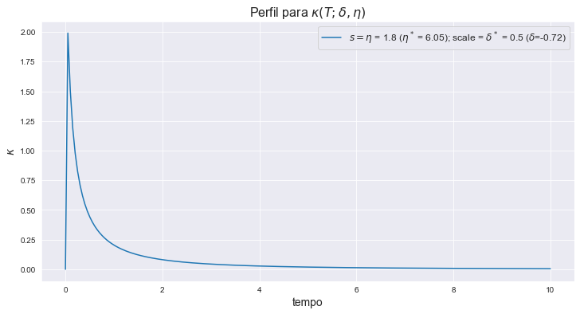

```python
delta = -0.72
eta = 1.8
T_int = np.linspace(0, 10, 200)

plt.figure(figsize=(12,6))
kappa = lognorm.pdf(T_int, s=eta, scale=np.exp(delta))
plt.plot(T_int, kappa, label=f'$s = \eta$ = {eta} ($\eta^*$ = {np.exp(eta):.2f}); '
         + f'scale = $\delta^*$ = {np.exp(delta):.1f} ($\delta$={delta})')
plt.legend(fontsize=12)
plt.xlabel('tempo', fontsize=14)
plt.ylabel('$\kappa$', fontsize=14)
plt.title('Perfil para $\kappa(T; \delta, \eta)$', fontsize=16)
plt.show()
```

### Outros perfis do termo de modulação

- Vamos, agora, incluir os valores extremos dos intervalos de confiança considerados para $\delta$ e $\nu$, em Ferguson et al (2005).
- Esses valores nos dão os seguintes perfis.

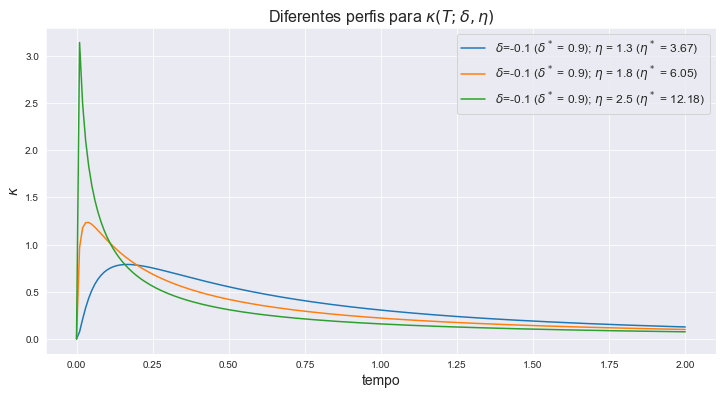

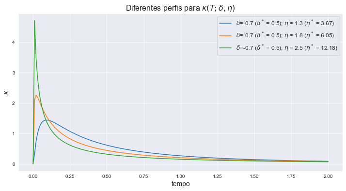

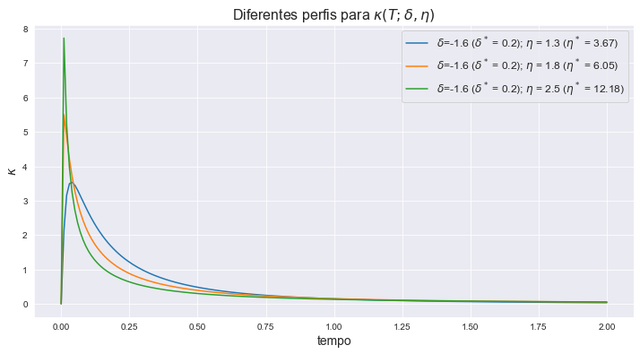

```python
T_int = np.linspace(0, 2, 200)
for delta in (-0.1, -0.7, -1.6):
    plt.figure(figsize=(12,6))
    for eta in (1.3, 1.8, 2.5):
        kappa = lognorm.pdf(T_int, s=eta, scale=np.exp(delta))
        plt.plot(T_int, kappa, label=f'$\delta$={delta} ($\delta^*$ = {np.exp(delta):.1f}); $\eta$ = {eta} ($\eta^*$ = {np.exp(eta):.2f})')
    plt.legend(fontsize=12)
    plt.xlabel('tempo', fontsize=14)
    plt.ylabel('$\kappa$', fontsize=14)
    plt.title('Diferentes perfis para $\kappa(T; \delta, \eta)$', fontsize=16)
    plt.show()
```

## Dados e ajuste para perfil de força de infecção da Figura 3 do artigo mencionado em Ferguson et al (2006)

- Os parâmetros em Ferguson et al (2005) e Ferguson et al (2006) foram retirados, segundo consta na Figura SI8 do material suplementar de Ferguson et al (2006), do artigo Hayden et al (1999).
- Os dados em Hayden et al (1999), no entanto, não foram disponibilizados.
- E não encontrei nenhuma figura em Hayden et al (1999) com valores e com um perfil próximo do exibido na Figura SI8 do material suplementar de Ferguson et al (2006)
- A única figura que me parece relevante para estar associada à carga viral é a dos dados de placebo da Figura 3 em [Hayden et al (1999)].
- Segue, abaixo, uma maneira manual de obter uma aproximação desses dados:
  - Capturar a figura do artigo em um arquivo de imagem tipo `png` ou outro.
  - Exibir a imagem em uma figura do `pyplot`
  - Sobrepor pontos, com as devidas coordenadas ajustadas manualmente, para que coincidam com os pontos da imagem.
  - Usar marcadores para acertar a escala.
  - Transformar os dados para a escala desejada.

### Carregando e exibindo a Figura 3

```
(1708, 1050)
```

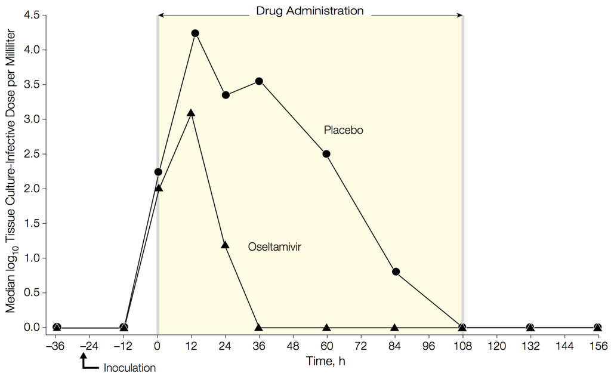

```python
Hayden_Fig3 = PIL_Image.open(path.join('..', 'input', 'modelos_individuais', 'Hayden_Fig3.png'))
print(Hayden_Fig3.size)
Hayden_Fig3
```

### Sobrepondo pontos para os dados de placebo

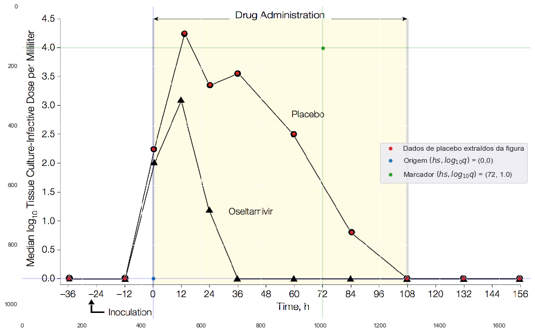

```python
plt.figure(figsize=(15,10))
plt.imshow(Hayden_Fig3)
x_pts = np.arange(0, 1708)
y_pts = np.arange(0, 1050)
x_org, y_org = 440, 914
x_mar, y_mar = 1008, 139
fig_x = np.array([156, 344, 440, 543, 629, 722, 912, 1104, 1290, 1480, 1668])
fig_y = np.array([914, 914, 478, 89, 262.8, 224, 427, 758, 914, 914, 914])
plt.plot(fig_x, fig_y, 'o', color='tab:red', markersize=5, label='Dados de placebo extraídos da figura')
plt.plot(x_org, y_org, 'o', color='tab:blue', markersize=5, label='Origem $(hs, log_{10}q)$ = (0,0)')
plt.plot(x_mar, y_mar, 'o', color='tab:green', markersize=5, label='Marcador $(hs, log_{10}q)$ = (72, 1.0)')
plt.plot(x_pts, y_org*np.ones_like(x_pts), 'b-', alpha=0.2)
plt.plot(x_org*np.ones_like(y_pts), y_pts, 'b-', alpha=0.2)
plt.plot(x_pts, y_mar*np.ones_like(x_pts), 'g-', alpha=0.2)
plt.plot(x_mar*np.ones_like(y_pts), y_pts, 'g-', alpha=0.2)
plt.legend(fontsize=12)
plt.show()
```

### Acertando os dados para as coordenadas da figura

- Os dados acima foram ajustados pelas coordenadas dos pontos.
- Vamos transformá-las para os valores da figura.
- Observe que o ponto $(0,0)$ da imagem corresponde aproximadamente a `(x_org, y_org) = (440, 914)` e o marcador $(72, 4.0)$ corresponde a `(x_mar, y_mar) = (1008, 139)`.
- Usando esses valores e sabendo que a abscissa está em escala linear e a ordenada, em escala $log_{10}$, fazemos a transformação dos pontos $(x_\textrm{pts}, y_\textrm{pts})$ em $(x,y_\textrm{log})$ de acordo com:

$$ x = 72\frac{x_\textrm{pts} - x_\textrm{org}}{x_\textrm{mar} - x_\textrm{org}}, \qquad y_\textrm{log} = 4\frac{y_\textrm{pts} - y_\textrm{org}}{y_\textrm{mar} - y_\textrm{org}} $$

e em seguida transformamos a escala logarítmica na ordenada para escala linear:

$$ y = 10^{y_\textrm{log}} $$

```python
x = 72*(fig_x - x_org)/(x_mar - x_org)
y_log = 4*(fig_y - y_org)/(y_mar - y_org)
y = 10**y_log
```

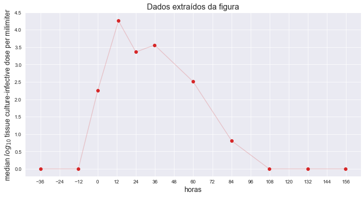

```python
plt.figure(figsize=(12,6))
plt.plot(x, y_log, 'o', color='tab:red')
plt.plot(x, y_log, '-', color='tab:red', alpha=0.2)
plt.xticks([-36 + 12*j for j in range(17)])
plt.yticks([0.5*j for j in range(10)])
plt.ylabel('median $log_{10}$ tissue culture-infective dose per milimiter', fontsize=14)
plt.xlabel('horas', fontsize=14)
plt.title('Dados extraídos da figura', fontsize=16)
plt.show()
```

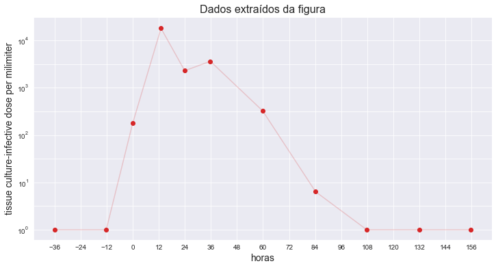

```python
plt.figure(figsize=(12,6))
plt.plot(x, y, 'o', color='tab:red')
plt.plot(x, y, '-', color='tab:red', alpha=0.2)
plt.yscale('log')
plt.xticks([-36 + 12*j for j in range(17)])
plt.yticks([10**(j/2) for j in range(10)])
plt.ylabel('tissue culture-infective dose per milimiter', fontsize=14)
plt.xlabel('horas', fontsize=14)
plt.title('Dados extraídos da figura', fontsize=16)
plt.show()
```

### Ajustando log-normal

```python
T_int = np.linspace(0, 156, 200)
fator_ajuste = 13500
delta = -0.4
eta = 0.5
kappa = fator_ajuste*lognorm.pdf(T_int/24, s=eta, scale=np.exp(delta))
```

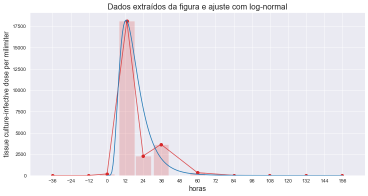

```python
plt.figure(figsize=(12,6))
plt.plot(x, y, 'o', color='tab:red')
plt.plot(x, y, '-', color='tab:red', alpha=0.8)
plt.bar(x, y, color='tab:red', width=10, alpha=0.2)
plt.plot(T_int, kappa, label=f'$\delta$={delta} ($\delta^*$ = {np.exp(delta):.1f}); $\eta$ = {eta} ($\eta^*$ = {np.exp(eta):.2f})')
plt.xticks([-36 + 12*j for j in range(17)])
plt.yticks([10**(j/2) for j in range(10)])
plt.yscale('linear')
plt.xlabel('horas', fontsize=14)
plt.ylabel('tissue culture-infective dose per milimiter', fontsize=14)
plt.title('Dados extraídos da figura e ajuste com log-normal', fontsize=16)
plt.show()
```

## Referências

- [Imperial College COVID-19 Response Team (16/mar/2020), Impact of non-pharmaceutical interventions (NPIs) to reduce COVID- 19 mortality and healthcare demand, 16 de março de 2020. (Free Download)](https://www.imperial.ac.uk/media/imperial-college/medicine/sph/ide/gida-fellowships/Imperial-College-COVID19-NPI-modelling-16-03-2020.pdf)
- [Ferguson NM, Cummings DAT, Fraser C, Cajka JC, Cooley PC, Burke DS (2006). Strategies for mitigating an influenza pandemic. Nature 442 (7101), 448–52 (Free Download)](https://pubmed.ncbi.nlm.nih.gov/16642006/); veja, também, as [notas suplementares](https://www.nature.com/articles/nature04795#Sec2).
- [Ferguson, N. M. et al. (2005), Strategies for containing an emerging influenza pandemic in Southeast Asia, Nature 437, 209-214.](https://pubmed.ncbi.nlm.nih.gov/16079797/) (Link para download [aqui](http://citeseerx.ist.psu.edu/viewdoc/download?doi=10.1.1.452.235&rep=rep1&type=pdf) disponibilizado por [CiteSeerX](http://citeseerx.ist.psu.edu/); veja, também, as [notas suplementares](https://static-content.springer.com/esm/art%3A10.1038%2Fnature04017/MediaObjects/41586_2005_BFnature04017_MOESM1_ESM.pdf).
- [Hayden et al (1999), Use of the oral neuraminidase inhibitor Oseltamivir in experimental human influenza, JAMA, Vol 282, no. 13, 1240--1246](https://jamanetwork.com/journals/jama/fullarticle/191957).
- [Lauer SA, Grantz KH, Bi Q, Jones FK, Zheng Q, Meredith HR, Azman AS, Reich NG, Lessler J (2020), The incubation period of coronavirus disease 2019 (COVID-19) from publicly reported confirmed cases: estimation and application, Ann Intern Med. M20-0504](https://dx.doi.org/10.7326%2FM20-0504)
- [Pellis L, Ball F, Trapman P. (2012), Reproduction numbers for epidemic models with households and other social structures. I. Definition and calculation of R_0, Mathe. Biosciences 235, 85--97](https://doi.org/10.1016/j.mbs.2011.10.009).
- [A. Svensson (2007), A note on generation times in epidemic models, Math. Biosciences, Volume 208, Issue 1, 300--311](https://doi.org/10.1016/j.mbs.2006.10.010).